# 624: Exponential Smoothing

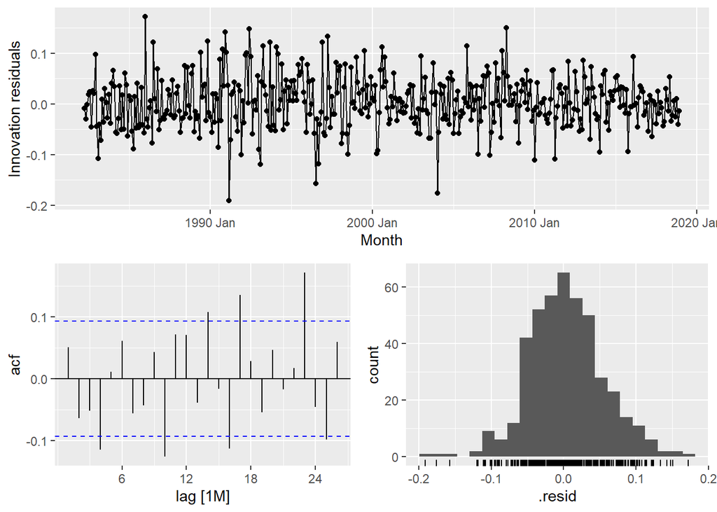

```r
retail_mod %>%
  select(Turnover_MAM) %>%
  gg_tsresiduals()
```

Now find the *test set RMSE*, while training the model to the end of 2010.

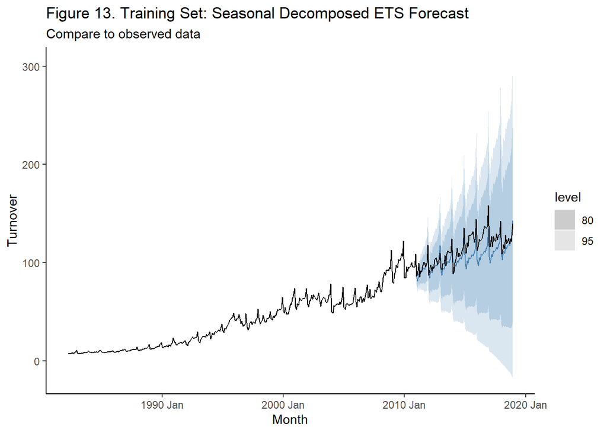

```r
# create train and test sets

train <- series %>%
  filter(year(Month) < 2011)

test<- series %>%
  filter(year(Month) > 2010)


# build model on train

train.mod<-train%>%
  model(train_MAM = ETS(Turnover ~ error("M") + trend("A") + season("M")))

# create forecast

train.fc<-train.mod%>%
  forecast(h=96)

#plot

train.fc%>%
  autoplot(series, color='steelblue')+
  labs(title='Figure 13. Training Set: Seasonal Decomposed ETS Forecast', subtitle='Compare to observed data')+
  theme_classic()
```

```r
# create function to calculate test RMSE

nrow <- nrow(test)
pred <- train.fc[6]
obs<- test$Turnover

rmse <- function(obs, pred, nrow){
  rmse <- sqrt(1/nrow*sum((pred-obs)^2))
  return (rmse)
}

test_rmse<-rmse(obs, pred, nrow)

str_glue('The RMSE of the Test set is', {test_rmse})
```

```
## The RMSE of the Test set is11.5450491482437
```

Can you beat the seasonal naïve approach from Exercise 7 in Section 5.11?

*Yes, the RMSE for the seasonal naive approach is 22.68. This is almost double that of the Holts Winter’s Multiplicative Model.*

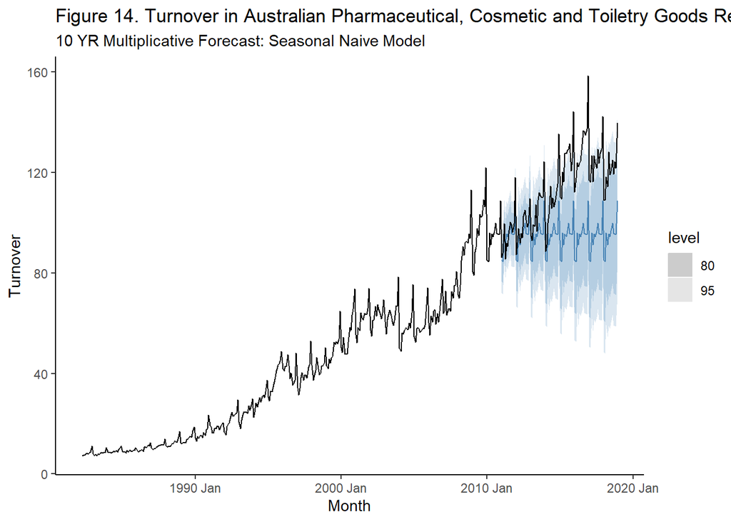

```r
#fit model

snaive <- train %>%
  model(SNAIVE(Turnover))

#forecast

snaive_fc <- snaive %>%
  forecast(new_data = anti_join(series, train))

#plot

snaive_fc%>%
  autoplot(series, color='steelblue')+
  labs(title='Figure 14. Turnover in Australian Pharmaceutical, Cosmetic and Toiletry Goods Retailing',
       subtitle = '10 YR Multiplicative Forecast: Seasonal Naive Model')+
  theme_classic()
```

```r
# assess Naive RMSE

snaive_fc %>% accuracy(series)%>%
  select(.model, RMSE)%>%
  rename(Model = '.model')%>%flextable()%>%
  set_caption('Turnover in Australian Pharmaceutical, Cosmetic and Toiletry Goods Retailing: RMSE for Seasonal Naive Model')
```

Turnover in Australian Pharmaceutical, Cosmetic and Toiletry Goods Retailing: RMSE for Seasonal Naive Model

| Model | RMSE |
| --- | --- |
| SNAIVE(Turnover) | 22.68981 |

# 6 Hyndman: Exercise 8.9

For the same retail data, try an STL decomposition applied to the Box-Cox transformed series, followed by ETS on the seasonally adjusted data. How does that compare with your best previous forecasts on the test set?

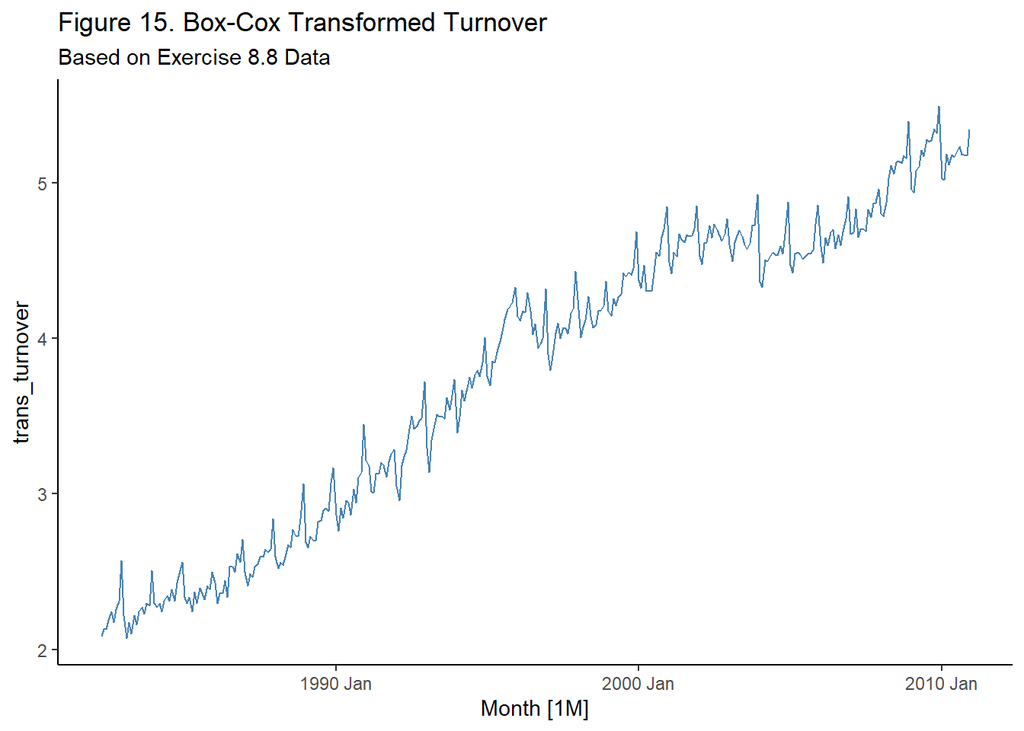

```r
#generate box-cox lambda

lambda <- train %>%
  features(Turnover, features = guerrero) %>%
  pull(lambda_guerrero)

# apply lambda to turnover

box_train<-train%>%
  mutate(trans_turnover = box_cox(Turnover, lambda))

# plot transformed turnover

box_train %>%
  autoplot(trans_turnover, color = 'steelblue') +
  labs(title = 'Figure 15. Box-Cox Transformed Turnover', subtitle='Based on Exercise 8.8 Data')+
  theme_classic()
```

Seasonally adjust the data.

*After some experimentation, I selected a trend window = 21, which is the default for STL. I also selected a seasonal window = ‘periodic’, which forces the seasonal component to be identical across years. In this instance, it produced good results.*

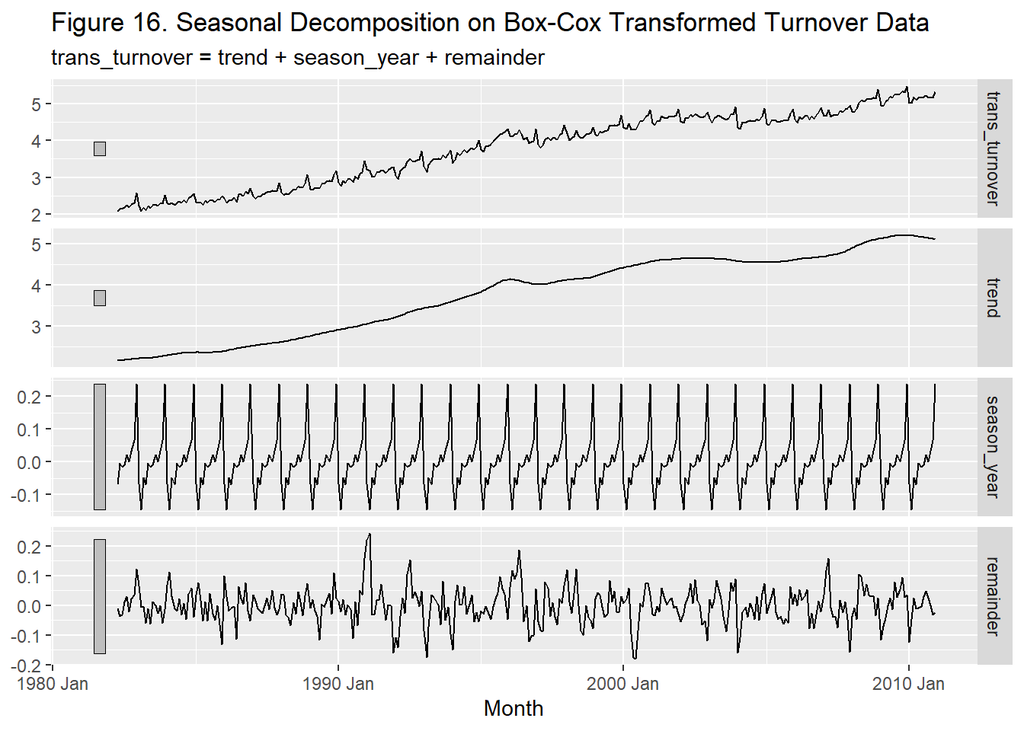

```r
decomp_train<-box_train %>%
  model(
    STL(trans_turnover ~ trend(window = 21) +  # 21 is STL default for monthly data
                   season(window='periodic'),
    robust = TRUE)) %>%
  components()

decomp_train%>%
  autoplot()+
  labs(title='Figure 16. Seasonal Decomposition on Box-Cox Transformed Turnover Data')
```

Apply ETS to seasonally adjusted data

*see: https://rdrr.io/cran/fabletools/man/decomposition_model.html*

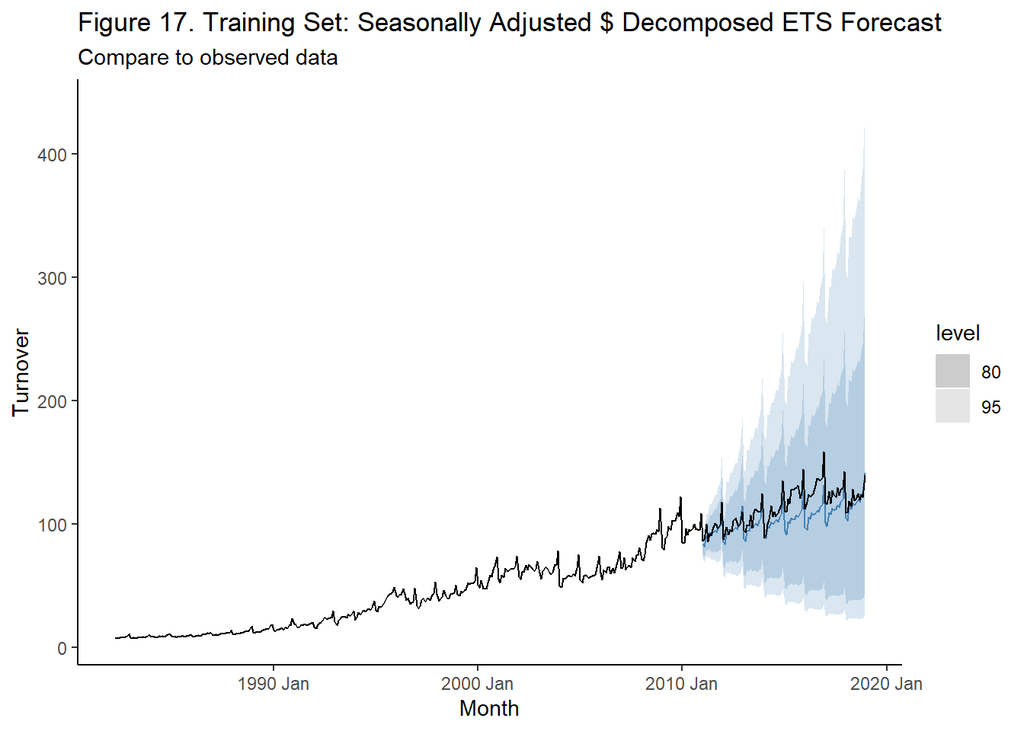

```r
# build model on train

train.stl.ets<-train%>%
  model(decomposition_model(
    STL(box_cox(Turnover, lambda)),
    ETS(season_adjust ~ error("M") + trend("Ad", phi=.98))))


#ETS(Turnover ~ error("M") + trend("Ad", phi=.8)

# create forecast

train.stl.ets.fc<-train.stl.ets%>%
  forecast(h=96)

#plot

train.stl.ets.fc%>%
  autoplot(series, color='steelblue')+
  labs(title='Figure 17. Training Set: Seasonally Adjusted $ Decomposed ETS Forecast', subtitle='Compare to observed data')+
  theme_classic()
```

```r
# calculate train and test RMSE using STL/ETS model

train.rmse<-train.stl.ets%>% accuracy()

nrow <- nrow(test)
pred <- train.stl.ets.fc[6]
obs<- test$Turnover

ets.stl.rmse <- function(obs, pred, nrow){
  rmse <- sqrt(1/nrow*sum((pred-obs)^2))
  return (rmse)
}

test.rmse<-ets.stl.rmse(obs, pred, nrow)


str_glue('The RMSE for STL/ETS training model is {train.rmse$RMSE}')
```

```
## The RMSE for STL/ETS training model is 2.36401973614103
```

```r
str_glue('The RMSE of the STL/ETS test set is ', {test.rmse})
```

```
## The RMSE of the STL/ETS test set is 12.1548069255932
```